# Data Wrangling for King Country, USA dataset

Norden Sherpa

```r
# Load necessary libraries
library(dplyr)
library(ggplot2)
```

```r
# reading and loading the csv file in data_file variable
data_file <- read.csv("kc_house_data.csv")
```

```r
# first insight into the data
head(data_file)
```

|  | id | date | price | bedrooms | bathrooms | sqft_living | sqft_lot | floors | waterfront | view | condition | grade | sqft_above | sqft_basement | yr_built | yr_renovated | zipcode | lat | long | sqft_living15 | sqft_lot15 |
| --- | --- | --- | --- | --- | --- | --- | --- | --- | --- | --- | --- | --- | --- | --- | --- | --- | --- | --- | --- | --- | --- |
| 1 | 7129300520 | 20141013T000000 | 221900 | 3 | 1.00 | 1180 | 5650 | 1 | 0 | 0 | 3 | 7 | 1180 | 0 | 1955 | 0 | 98178 | 47.5112 | -122.257 | 1340 | 5650 |
| 2 | 6414100192 | 20141209T000000 | 538000 | 3 | 2.25 | 2570 | 7242 | 2 | 0 | 0 | 3 | 7 | 2170 | 400 | 1951 | 1991 | 98125 | 47.7210 | -122.319 | 1690 | 7639 |
| 3 | 5631500400 | 20150225T000000 | 180000 | 2 | 1.00 | 770 | 10000 | 1 | 0 | 0 | 3 | 6 | 770 | 0 | 1933 | 0 | 98028 | 47.7379 | -122.233 | 2720 | 8062 |
| 4 | 2487200875 | 20141209T000000 | 604000 | 4 | 3.00 | 1960 | 5000 | 1 | 0 | 0 | 5 | 7 | 1050 | 910 | 1965 | 0 | 98136 | 47.5208 | -122.393 | 1360 | 5000 |
| 5 | 1954400510 | 20150218T000000 | 510000 | 3 | 2.00 | 1680 | 8080 | 1 | 0 | 0 | 3 | 8 | 1680 | 0 | 1987 | 0 | 98074 | 47.6168 | -122.045 | 1800 | 7503 |
| 6 | 7237550310 | 20140512T000000 | 1225000 | 4 | 4.50 | 5420 | 101930 | 1 | 0 | 0 | 3 | 11 | 3890 | 1530 | 2001 | 0 | 98053 | 47.6561 | -122.005 | 4760 | 101930 |

```r
# looking at the structure of the data
str(data_file)
```

```
'data.frame':   21613 obs. of  21 variables:
 $ id           : num  7.13e+09 6.41e+09 5.63e+09 2.49e+09 1.95e+09 ...
 $ date         : chr  "20141013T000000" "20141209T000000" "20150225T000000" "20141209T000000" ...
 $ price        : num  221900 538000 180000 604000 510000 ...
 $ bedrooms     : int  3 3 2 4 3 4 3 3 3 3 ...
 $ bathrooms    : num  1 2.25 1 3 2 4.5 2.25 1.5 1 2.5 ...
 $ sqft_living  : int  1180 2570 770 1960 1680 5420 1715 1060 1780 1890 ...
 $ sqft_lot     : int  5650 7242 10000 5000 8080 101930 6819 9711 7470 6560 ...
 $ floors       : num  1 2 1 1 1 1 2 1 1 2 ...
 $ waterfront   : int  0 0 0 0 0 0 0 0 0 0 ...
 $ view         : int  0 0 0 0 0 0 0 0 0 0 ...
 $ condition    : int  3 3 3 5 3 3 3 3 3 3 ...
 $ grade        : int  7 7 6 7 8 11 7 7 7 7 ...
 $ sqft_above   : int  1180 2170 770 1050 1680 3890 1715 1060 1050 1890 ...
 $ sqft_basement: int  0 400 0 910 0 1530 0 0 730 0 ...
 $ yr_built     : int  1955 1951 1933 1965 1987 2001 1995 1963 1960 2003 ...
 $ yr_renovated : int  0 1991 0 0 0 0 0 0 0 0 ...
 $ zipcode      : int  98178 98125 98028 98136 98074 98053 98003 98198 98146 98038 ...
 $ lat          : num  47.5 47.7 47.7 47.5 47.6 ...
 $ long         : num  -122 -122 -122 -122 -122 ...
 $ sqft_living15: int  1340 1690 2720 1360 1800 4760 2238 1650 1780 2390 ...
 $ sqft_lot15   : int  5650 7639 8062 5000 7503 101930 6819 9711 8113 7570 ...
```

```r
# summary of the data
summary(data_file)
```

```
       id                date               price            bedrooms        bathrooms
 Min.   :1.000e+06   Length:21613       Min.   :  75000   Min.   : 0.000   Min.   :0.000
 1st Qu.:2.123e+09   Class :character   1st Qu.: 321950   1st Qu.: 3.000   1st Qu.:1.750
 Median :3.905e+09   Mode  :character   Median : 450000   Median : 3.000   Median :2.250
 Mean   :4.580e+09                      Mean   : 540088   Mean   : 3.371   Mean   :2.115
 3rd Qu.:7.309e+09                      3rd Qu.: 645000   3rd Qu.: 4.000   3rd Qu.:2.500
 Max.   :9.900e+09                      Max.   :7700000   Max.   :33.000   Max.   :8.000
  sqft_living       sqft_lot           floors        waterfront            view
 Min.   :  290   Min.   :    520   Min.   :1.000   Min.   :0.000000   Min.   :0.0000
 1st Qu.: 1427   1st Qu.:   5040   1st Qu.:1.000   1st Qu.:0.000000   1st Qu.:0.0000
 Median : 1910   Median :   7618   Median :1.500   Median :0.000000   Median :0.0000
 Mean   : 2080   Mean   :  15107   Mean   :1.494   Mean   :0.007542   Mean   :0.2343
 3rd Qu.: 2550   3rd Qu.:  10688   3rd Qu.:2.000   3rd Qu.:0.000000   3rd Qu.:0.0000
 Max.   :13540   Max.   :1651359   Max.   :3.500   Max.   :1.000000   Max.   :4.0000
   condition         grade          sqft_above   sqft_basement       yr_built
 Min.   :1.000   Min.   : 1.000   Min.   : 290   Min.   :   0.0   Min.   :1900
 1st Qu.:3.000   1st Qu.: 7.000   1st Qu.:1190   1st Qu.:   0.0   1st Qu.:1951
 Median :3.000   Median : 7.000   Median :1560   Median :   0.0   Median :1975
 Mean   :3.409   Mean   : 7.657   Mean   :1788   Mean   : 291.5   Mean   :1971
 3rd Qu.:4.000   3rd Qu.: 8.000   3rd Qu.:2210   3rd Qu.: 560.0   3rd Qu.:1997
 Max.   :5.000   Max.   :13.000   Max.   :9410   Max.   :4820.0   Max.   :2015
  yr_renovated       zipcode           lat             long        sqft_living15
 Min.   :   0.0   Min.   :98001   Min.   :47.16   Min.   :-122.5   Min.   : 399
 1st Qu.:   0.0   1st Qu.:98033   1st Qu.:47.47   1st Qu.:-122.3   1st Qu.:1490
 Median :   0.0   Median :98065   Median :47.57   Median :-122.2   Median :1840
 Mean   :  84.4   Mean   :98078   Mean   :47.56   Mean   :-122.2   Mean   :1987
 3rd Qu.:   0.0   3rd Qu.:98118   3rd Qu.:47.68   3rd Qu.:-122.1   3rd Qu.:2360
 Max.   :2015.0   Max.   :98199   Max.   :47.78   Max.   :-121.3   Max.   :6210
   sqft_lot15
 Min.   :   651
 1st Qu.:  5100
 Median :  7620
 Mean   : 12768
 3rd Qu.: 10083
 Max.   :871200
```

```r
# looking for nan or null variables in the datafile
paste("total rows of the dataset: ", nrow(data_file))
```

```
[1] "total rows of the dataset:  21613"
```

```r
paste("summmary of the dataset")
```

```
[1] "summmary of the dataset"
```

```r
summary(is.na(data_file))
```

```
     id             date           price          bedrooms       bathrooms
 Mode :logical   Mode :logical   Mode :logical   Mode :logical   Mode :logical
 FALSE:21613     FALSE:21613     FALSE:21613     FALSE:21613     FALSE:21613
 sqft_living      sqft_lot         floors        waterfront         view
 Mode :logical   Mode :logical   Mode :logical   Mode :logical   Mode :logical
 FALSE:21613     FALSE:21613     FALSE:21613     FALSE:21613     FALSE:21613
 condition         grade         sqft_above      sqft_basement    yr_built
 Mode :logical   Mode :logical   Mode :logical   Mode :logical   Mode :logical
 FALSE:21613     FALSE:21613     FALSE:21613     FALSE:21613     FALSE:21613
 yr_renovated     zipcode           lat             long         sqft_living15
 Mode :logical   Mode :logical   Mode :logical   Mode :logical   Mode :logical
 FALSE:21613     FALSE:21613     FALSE:21613     FALSE:21613     FALSE:21613
 sqft_lot15
 Mode :logical
 FALSE:21613
```

# since we do not have null variable inside our dataset we do not have to deal with the missing variables

```r
# looking if the dataset contains any type of duplicate values
paste("looking for duplicate values in the dataset: ", sum(duplicated(data_file)))
```

```
[1] "looking for duplicate values in the dataset:  0"
```

```r
summary(duplicated(data_file))
```

```
   Mode   FALSE
logical   21613
```

# since we do not have duplicate variables in the dataset, we do not have to deal with the duplicate values.

# after looking at the structure of the dataset the data is not in the type date so changing the date format

```r
# Converting the 'date' column to a date format
data_file$date <- as.Date(data_file$date, format="%Y%m%dT%H%M%S")
```

# looking if any column is irrelevant for modeling or analysis

```r
clean_data_file <- data_file %>% select(-id)
```

# since, id column is irrelevant or does not help with with analysis so drpping the id column

# outlier detection

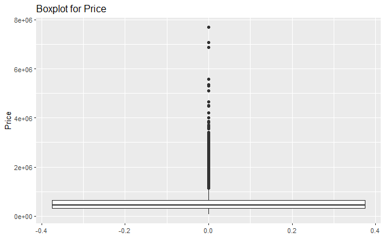

```r
# Boxplot before outlier handling
ggplot(clean_data_file, aes(y = price)) +
  geom_boxplot() +
  labs(title = "Boxplot for Price", y = "Price")
```

# IQR method:

```r
# Detecting outliers using the IQR method for price
Q1 <- quantile(clean_data_file$price, 0.25)
Q3 <- quantile(clean_data_file$price, 0.75)
IQR_value <- IQR(clean_data_file$price)
paste("fist quartile: ", Q1)
```

```
[1] "fist quartile:  321950"
```

```r
paste("third quartile: ", Q3)
```

```
[1] "third quartile:  645000"
```

```r
paste("Inter quartile range: ", IQR_value)
```

```
[1] "Inter quartile range:  323050"
```

```r
# Calculating the lower and upper bound
lower_bound <- Q1 - 1.5 * IQR_value
upper_bound <- Q3 + 1.5 * IQR_value
paste("lower bound of the dataset for price: ", lower_bound)
```

```
[1] "lower bound of the dataset for price:  -162625"
```

```r
paste("upper bound of the dataset for price: ", upper_bound)
```

```
[1] "upper bound of the dataset for price:  1129575"
```

# Z-scores method:

```r
# Z-Score Method for Outliers
mean_price <- mean(clean_data_file$price)
std_price <- sd(clean_data_file$price)

# Calculate Z-scores
clean_data_file$z_scores <- (clean_data_file$price - mean_price) / std_price

paste("mean price: ", mean_price)
```

```
[1] "mean price:  540088.141766529"
```

```r
paste("standard price: ", std_price)
```

```
[1] "standard price:  367127.1964827"
```

```r
paste("z-score value: ", summary(clean_data_file$z_scores))
```

```
[1] "z-score value:  -1.26683107713717"     "z-score value:  -0.594175925555024"
[3] "z-score value:  -0.245386728713177"    "z-score value:  -3.79449340190976e-17"
[5] "z-score value:  0.285764332467302"     "z-score value:  19.5025373408174"
```

# outlier detection:

```r
# IQR - filtering out the outliers
cleaned_data_IQR <- clean_data_file %>% filter(price >= lower_bound & price <= upper_bound)
cat("Number of observations after IQR outlier removal:", nrow(cleaned_data_IQR), "\n")
```

```
Number of observations after IQR outlier removal: 20467
```

```r
#Z-Scores - Filterign out the outliers (Z-score greater than 3 or less than -3)
cleaned_data_Z <- clean_data_file %>% filter(abs(z_scores) <= 3)

cat("Number of observations after Z-score outlier removal:", nrow(cleaned_data_Z), "\n")
```

```
Number of observations after Z-score outlier removal: 21207
```

# removing the outliers from the dataset

```r
# z-scores
clean_data_file <- clean_data_file %>% filter(abs(z_scores) <= 3)
# IQR
clean_data_file <- clean_data_file %>% filter(price >= lower_bound & price <= upper_bound)
```

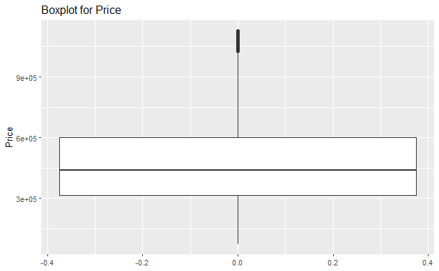

```r
# Boxplot after outlier handling
ggplot(clean_data_file, aes(y = price)) +
  geom_boxplot() +
  labs(title = "Boxplot for Price", y = "Price")
```

```r
# Droping the z_scores column after filtering
clean_data_file <- clean_data_file %>% select(-z_scores)
```

```r
paste("No. of rows before outlier handling: ", nrow(data_file))
```

```
[1] "No. of rows before outlier handling:  21613"
```

```r
paste("No. of rows after outlier handling: ", nrow(clean_data_file))
```

```
[1] "No. of rows after outlier handling:  20467"
```

# Observation: The IQR method removed more outliers (1,146) compared to the Z-score method (406). This suggests that IQR is stricter, where as z-scores is more conservative.

# For correlation matrix of the dataset

```r
library(reshape2)

# Calculating correlation matrix
cor_matrix <- cor(clean_data_file[, sapply(clean_data_file, is.numeric)])

# Extracting correlations with price
price_correlation <- cor_matrix[,"price"]

# correlations sorted by strength
price_correlation <- sort(price_correlation, decreasing = TRUE)
print(price_correlation)
```

```
        price         grade   sqft_living sqft_living15    sqft_above     bathrooms
   1.00000000    0.63118229    0.62233293    0.56208951    0.53045093    0.45592735
          lat      bedrooms        floors          view sqft_basement      sqft_lot
   0.43076175    0.29695608    0.27398682    0.23826772    0.23570129    0.09394992
 yr_renovated    sqft_lot15          long      yr_built    waterfront     condition
   0.08360103    0.08242009    0.07086321    0.06114392    0.05144866    0.03827501
      zipcode
  -0.01851064
```

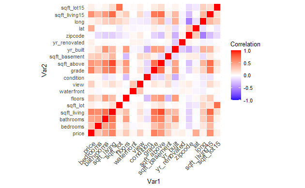

```r
# Visualizing the correlation matrix using heatmap
cor_matrix_melt <- melt(cor_matrix)
ggplot(data = cor_matrix_melt, aes(Var1, Var2, fill = value)) +
  geom_tile(color = "white") +
  scale_fill_gradient2(low = "blue", high = "red", mid = "white",
                       midpoint = 0, limit = c(-1,1), space = "Lab",
                       name="Correlation") +
  theme_minimal() +
  theme(axis.text.x = element_text(angle = 45, vjust = 1,
                                   size = 12, hjust = 1)) +
  coord_fixed()
```

# The heatmap reveals the correlation between variables, making it easy to spot highly correlated variables with price. Sqft_living and grade stand out.

# After looking at the correlation matrix we can see that some columns are weakly correlated to the price of the house so removing the columns with respect to the correlation matrices shown above:

```r
cleaned_data_file <- clean_data_file %>%
  select(-c(waterfront, yr_renovated, sqft_lot, sqft_lot15, yr_built, condition, zipcode))
```

```r
head(cleaned_data_file)
```

|  | date | price | bedrooms | bathrooms | sqft_living | floors | view | grade | sqft_above | sqft_basement | lat | long | sqft_living15 |
| --- | --- | --- | --- | --- | --- | --- | --- | --- | --- | --- | --- | --- | --- |
| 1 | 2014-10-13 | 221900 | 3 | 1.00 | 1180 | 1 | 0 | 7 | 1180 | 0 | 47.5112 | -122.257 | 1340 |
| 2 | 2014-12-09 | 538000 | 3 | 2.25 | 2570 | 2 | 0 | 7 | 2170 | 400 | 47.7210 | -122.319 | 1690 |
| 3 | 2015-02-25 | 180000 | 2 | 1.00 | 770 | 1 | 0 | 6 | 770 | 0 | 47.7379 | -122.233 | 2720 |
| 4 | 2014-12-09 | 604000 | 4 | 3.00 | 1960 | 1 | 0 | 7 | 1050 | 910 | 47.5208 | -122.393 | 1360 |
| 5 | 2015-02-18 | 510000 | 3 | 2.00 | 1680 | 1 | 0 | 8 | 1680 | 0 | 47.6168 | -122.045 | 1800 |
| 6 | 2014-06-27 | 257500 | 3 | 2.25 | 1715 | 2 | 0 | 7 | 1715 | 0 | 47.3097 | -122.327 | 2238 |

# seperating the features and target to make the dataframe more arranged,

```r
cleaned_data_file <- cleaned_data_file %>%
  select(-price, everything(), price)
```

```r
head(cleaned_data_file)
```

|  | date | bedrooms | bathrooms | sqft_living | floors | view | grade | sqft_above | sqft_basement | lat | long | sqft_living15 | price |
| --- | --- | --- | --- | --- | --- | --- | --- | --- | --- | --- | --- | --- | --- |
| 1 | 2014-10-13 | 3 | 1.00 | 1180 | 1 | 0 | 7 | 1180 | 0 | 47.5112 | -122.257 | 1340 | 221900 |
| 2 | 2014-12-09 | 3 | 2.25 | 2570 | 2 | 0 | 7 | 2170 | 400 | 47.7210 | -122.319 | 1690 | 538000 |
| 3 | 2015-02-25 | 2 | 1.00 | 770 | 1 | 0 | 6 | 770 | 0 | 47.7379 | -122.233 | 2720 | 180000 |
| 4 | 2014-12-09 | 4 | 3.00 | 1960 | 1 | 0 | 7 | 1050 | 910 | 47.5208 | -122.393 | 1360 | 604000 |
| 5 | 2015-02-18 | 3 | 2.00 | 1680 | 1 | 0 | 8 | 1680 | 0 | 47.6168 | -122.045 | 1800 | 510000 |
| 6 | 2014-06-27 | 3 | 2.25 | 1715 | 2 | 0 | 7 | 1715 | 0 | 47.3097 | -122.327 | 2238 | 257500 |

```r
str(cleaned_data_file)
```

```
'data.frame':   20467 obs. of  13 variables:
 $ date         : Date, format: "2014-10-13" "2014-12-09" "2015-02-25" ...
 $ bedrooms     : int  3 3 2 4 3 3 3 3 3 3 ...
 $ bathrooms    : num  1 2.25 1 3 2 2.25 1.5 1 2.5 2.5 ...
 $ sqft_living  : int  1180 2570 770 1960 1680 1715 1060 1780 1890 3560 ...
 $ floors       : num  1 2 1 1 1 2 1 1 2 1 ...
 $ view         : int  0 0 0 0 0 0 0 0 0 0 ...
 $ grade        : int  7 7 6 7 8 7 7 7 7 8 ...
 $ sqft_above   : int  1180 2170 770 1050 1680 1715 1060 1050 1890 1860 ...
 $ sqft_basement: int  0 400 0 910 0 0 0 730 0 1700 ...
 $ lat          : num  47.5 47.7 47.7 47.5 47.6 ...
 $ long         : num  -122 -122 -122 -122 -122 ...
 $ sqft_living15: int  1340 1690 2720 1360 1800 2238 1650 1780 2390 2210 ...
 $ price        : num  221900 538000 180000 604000 510000 ...
```

```r
# Check for NA values in the training data
summary (is.na(cleaned_data_file))
```

```
    date          bedrooms       bathrooms       sqft_living       floors
 Mode :logical   Mode :logical   Mode :logical   Mode :logical   Mode :logical
 FALSE:20467     FALSE:20467     FALSE:20467     FALSE:20467     FALSE:20467
    view           grade         sqft_above      sqft_basement      lat
 Mode :logical   Mode :logical   Mode :logical   Mode :logical   Mode :logical
 FALSE:20467     FALSE:20467     FALSE:20467     FALSE:20467     FALSE:20467
    long         sqft_living15     price
 Mode :logical   Mode :logical   Mode :logical
 FALSE:20467     FALSE:20467     FALSE:20467
```

# saving the clean data to a new csv file

```r
write.csv(cleaned_data_file, "cleaned_data_file.csv", row.names = FALSE)
```